# Appendix 4: Documentation of Code

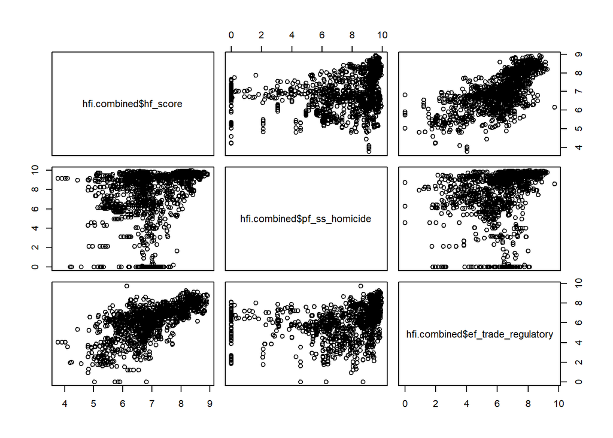

```r
pairs(~hfi.combined$hf_score+hfi.combined$pf_ss_homicide+hfi.combined$ef_trade_regulatory)
```

The above pairs pot suggest the following predictors might have the clearest non-linear relationships with hf_score: pf_ss_homicide and ef_trade_regulatory. Let’s test this with polynomial regression:

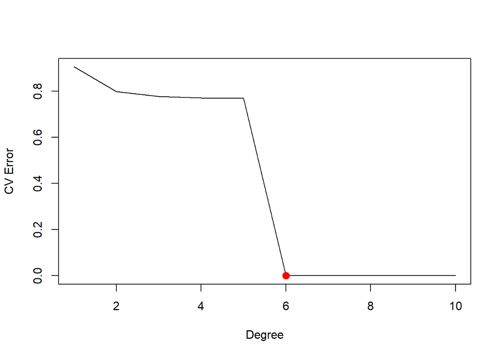

```r
set.seed(111)
CVerror = rep(0, 10)
for (i in 1:5) {
    fit = glm(hf_score~ poly(pf_ss_homicide, i), data = hfi.combined)
    CVerror[i] = cv.glm(hfi.combined, fit, K = 10)$delta[1]
}
plot(CVerror, xlab = "Degree", ylab = "CV Error", type = "l")
points(which.min(CVerror), CVerror[which.min(CVerror)], col = "red",cex=2,pch =20)
```

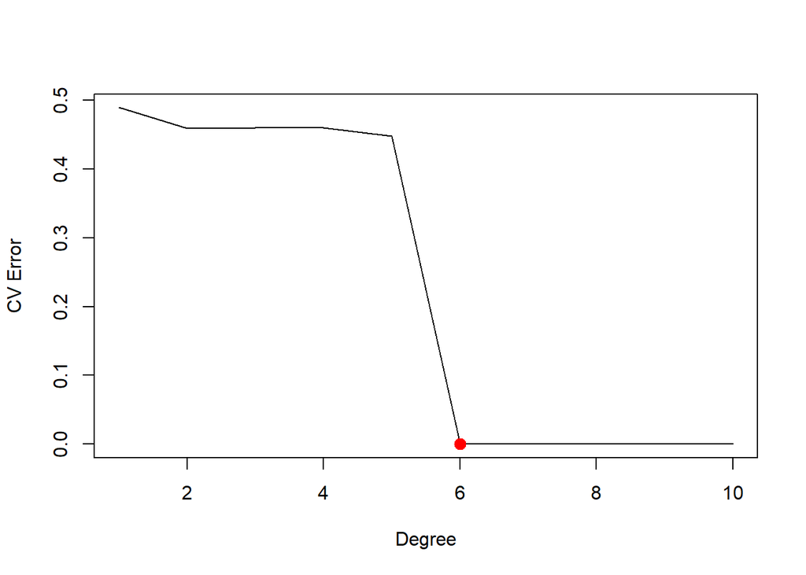

```r
set.seed(111)
CVerror = rep(0, 10)
for (i in 1:5) {
    fit = glm(hf_score~ poly(ef_trade_regulatory, i), data = hfi.combined)
    CVerror[i] = cv.glm(hfi.combined, fit, K = 10)$delta[1]
}
plot(CVerror, xlab = "Degree", ylab = "CV Error", type = "l")
points(which.min(CVerror), CVerror[which.min(CVerror)], col = "red",cex=2,pch =20)
```

```r
polyfit=lm(hf_score~ pf_ss_homicide,data=hfi.combined)
polyfit2=lm(hf_score~poly(pf_ss_homicide ,2),data=hfi.combined)
polyfit3=lm(hf_score~poly(pf_ss_homicide ,3),data=hfi.combined)
polyfit4=lm(hf_score~poly(pf_ss_homicide ,4),data=hfi.combined)
polyfit5=lm(hf_score~poly(pf_ss_homicide ,5),data=hfi.combined)
polyfit6=lm(hf_score~poly(pf_ss_homicide ,6),data=hfi.combined)
anova(polyfit, polyfit2, polyfit3, polyfit4, polyfit5, polyfit6)
```

|  | Res.Df | RSS | Df | Sum of Sq | F | Pr(>F) |
| --- | --- | --- | --- | --- | --- | --- |
| 1 | 1303 | 1174.7873 | NA | NA | NA | NA |
| 2 | 1302 | 1037.2584 | 1 | 137.528918 | 180.069501 | 1.525053e-38 |
| 3 | 1301 | 1008.7683 | 1 | 28.490142 | 37.302742 | 1.334221e-09 |
| 4 | 1300 | 997.9434 | 1 | 10.824858 | 14.173213 | 1.741782e-04 |
| 5 | 1299 | 994.3896 | 1 | 3.553835 | 4.653111 | 3.118041e-02 |
| 6 | 1298 | 991.3535 | 1 | 3.036056 | 3.975173 | 4.638467e-02 |

```r
polyfit=lm(hf_score~ ef_trade_regulatory,data=hfi.combined)
polyfit2=lm(hf_score~poly(ef_trade_regulatory ,2),data=hfi.combined)
polyfit3=lm(hf_score~poly(ef_trade_regulatory ,3),data=hfi.combined)
polyfit4=lm(hf_score~poly(ef_trade_regulatory ,4),data=hfi.combined)
polyfit5=lm(hf_score~poly(ef_trade_regulatory ,5),data=hfi.combined)
polyfit6=lm(hf_score~poly(ef_trade_regulatory ,6),data=hfi.combined)
anova(polyfit, polyfit2, polyfit3, polyfit4, polyfit5,polyfit6)
```

|  | Res.Df | RSS | Df | Sum of Sq | F | Pr(>F) |
| --- | --- | --- | --- | --- | --- | --- |
| 1 | 1303 | 636.5059 | NA | NA | NA | NA |
| 2 | 1302 | 596.3467 | 1 | 40.15917239 | 91.1245076 | 6.432665e-21 |
| 3 | 1301 | 596.2794 | 1 | 0.06727497 | 0.1526525 | 6.960774e-01 |
| 4 | 1300 | 595.5188 | 1 | 0.76068752 | 1.7260633 | 1.891466e-01 |
| 5 | 1299 | 575.9906 | 1 | 19.52819010 | 44.3110901 | 4.122528e-11 |
| 6 | 1298 | 572.0372 | 1 | 3.95339566 | 8.9705841 | 2.795604e-03 |

Using a fifth degree polynomial for pf_ss_homicide and a sixth degree polynomial for ef_trade_regulatory of these two variables and including the other eight predictors:

```r
set.seed(111)
    fit = glm(hf_score~ pf_movement_domestic+
                pf_expression_control+
                pf_identity_sex_male+
                ef_legal_courts+
                ef_legal_gender+
                ef_money_sd+
                ef_money_currency+
                poly(pf_ss_homicide, 5)+
                ef_regulation_credit+
                poly(ef_trade_regulatory, 6), data = hfi.combined)
    CVerror.poly= cv.glm(hfi.combined, fit, K = 10)$delta[1]
    CVerror.poly
```

```
## [1] 0.07717087
```

```r
    fit11=CVerror.poly
```